# GPP Summary

Gross found that migration to freshwater is more frequent in tropical latitudes, where freshwater productivity is greater than that of oceans. He found three important patterns in his data.

1. Freshwater productivity is higher than ocean productivity at low latitudes.
2. Ocean productivity is higher than freshwater at high latitudes.
3. Ocean productivity is generally higher at high latitudes and low at equatorial latitudes. The opposite is true for freshwater.

##### Fig 1. Mean & Stdev GPP by latitude w/ hemispheres on x-axis

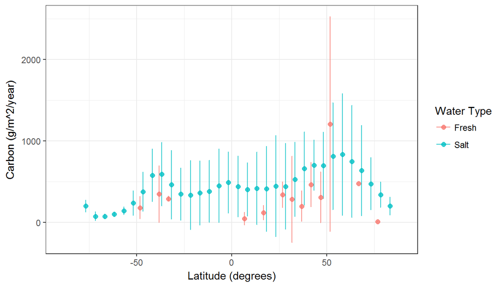

##### Fig 2. Median & interquartile GPP by latitude w/ hemispheres on x-axis

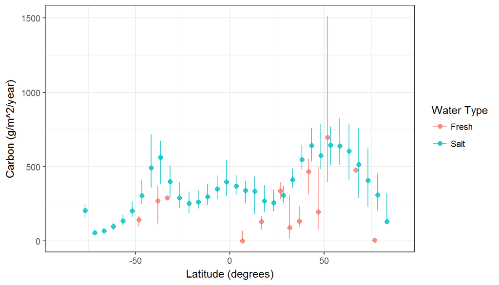

The patterns that ocean productivity increases with latitude, while freshwater productivity decreases with latitude are more complicated.

Freshwater productivity does not show any meaningful trend. The sample size for freshwater is very small (140 data points), so there is no way to know if the lack of trend is because of data or because there is no trend. There is data to show that freshwater productivity is heavily influenced by pollution (Finlay 2011), stream size (McTammany et al. , Finlay 2011), season (Minshall et al. 1992), and watershed area (Finlay 2011). It is likely that even if there is a decreasing trend with latitude, it would be hard to detect without accounting for these other important factors (which we can’t do very well because our data size is so small).

##### Fig 3. Mean & Stdev GPP by latitude w/ hemispheres as factor w/ facet on water type

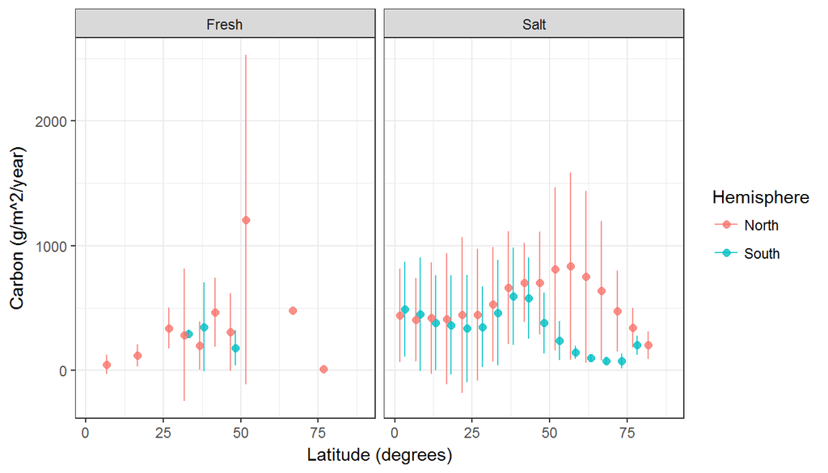

##### Fig. 4 Median & interquartile GPP by latitude w/ hemispheres as factor w/ facet on water type

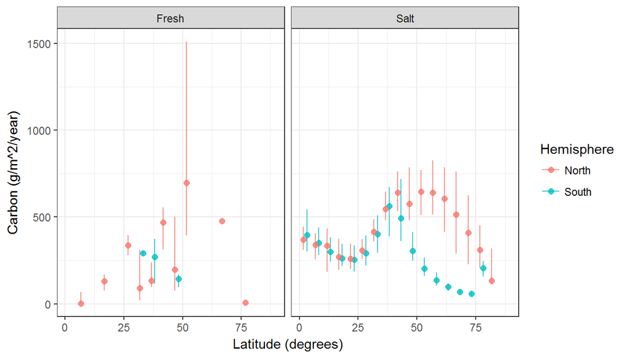

Another really important point is that latitude is a very poor predictor of ocean productivity. Both the boxplots and map show this well (Figures 5, 6). In the box plots you can see that the data spread by latitude is enormous and the mean doesn’t really capture what’s going on with productivity in a meaningful way.

##### Fig 5. Boxplots of ocean GPP w/ hemispheres included in x-axis

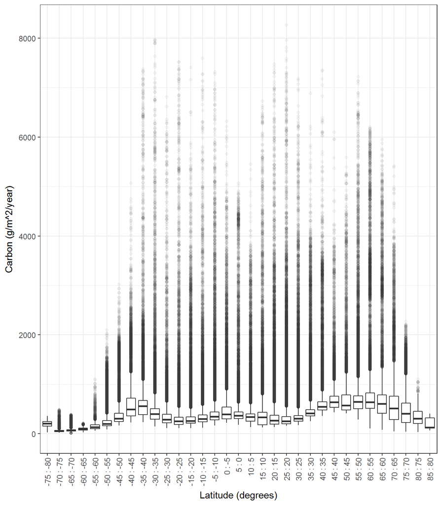

##### Fig 6. Map of GPP distribution

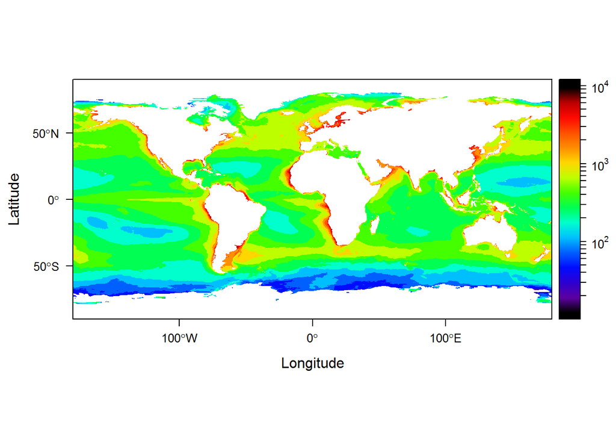

Much of this spread is because productivity is so much higher near land than it is in the ocean. The map shows this well, as does the black dot plot (Figures 7, 8). This might play an important role in patterns of diadromy if some groups are only using the nearshore, whereas others migrate farther from shore.

##### Fig 7. GPP by distance from land

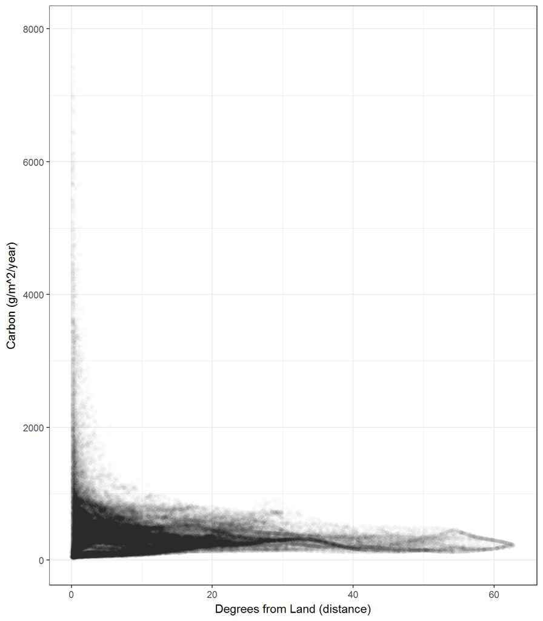

##### Fig 8. GPP by distance from land for 5 degree latitude bins

[figure not shown]